# README

**REQUIRED** — A Linode Account and Personal Access Token is required to use this module.

Follow the steps below to learn how to generate a token and enter it into the Linode Bandwidth module.

## Steps to finish setup

- Login into Linode
- Create a Personal Access Token
- Enter the token into the Linode Bandwidth module

## What is a Personal Access Token and why do I need it?

A Personal Access Token is a way for a server to grant access to data that requires authentication without the need for a Username and Password. The Linode API requires this token in order for the module to lookup the bandwidth usage for your account.

## Logging into Linode

- Click the following link to open the [Login Page](https://login.linode.com/login)
- Follow the on screen steps to log into Linode.
- Once you’ve logged in click the following link to open the [API Tokens page](https://cloud.linode.com/profile/tokens)
- Continue to the next step to create your Personal Access Token.

## Creating a Personal Access Token

Once you’ve loaded the API Tokens page you will be brought to a page that looks like:

[figure not shown]

- Locate and `click` the `+ Add a Personal Access Token’` link

[figure not shown]

- A form will open from the right hand side of the screen

[figure not shown]

- Fill out the form as follows:

```
Label: Infinity Dashboard Module

Expiry: Never

Access: Account - Read Only
```

[figure not shown]

- Click the `Submit` button to continue to the next step.

## Saving your Personal Access Token

After clicking the `Submit` button a popup will open that contains your Personal Access Token. This token will only be displayed once so make sure to record it before dismissing the popup.

- Copy the Personal Access Token by performing a `Right Click` and selecting the `Copy` action on the token.

[figure not shown]

- Click the `Okay` button to dismiss this popup.
- You may now close the API Keys browser window.

## Entering your Personal Access Token into Infinity Dashboard

- Open Infinity Dashboard
- Click on the ‘Module Config’ item in the sidebar
- Locate the Linode Bandwidth module you want to configure
- Click the Pencil icon to open the module configuration
- Locate the **Personal Access Token** config option
- Click the **Your Personal Access Token from Linode** text field

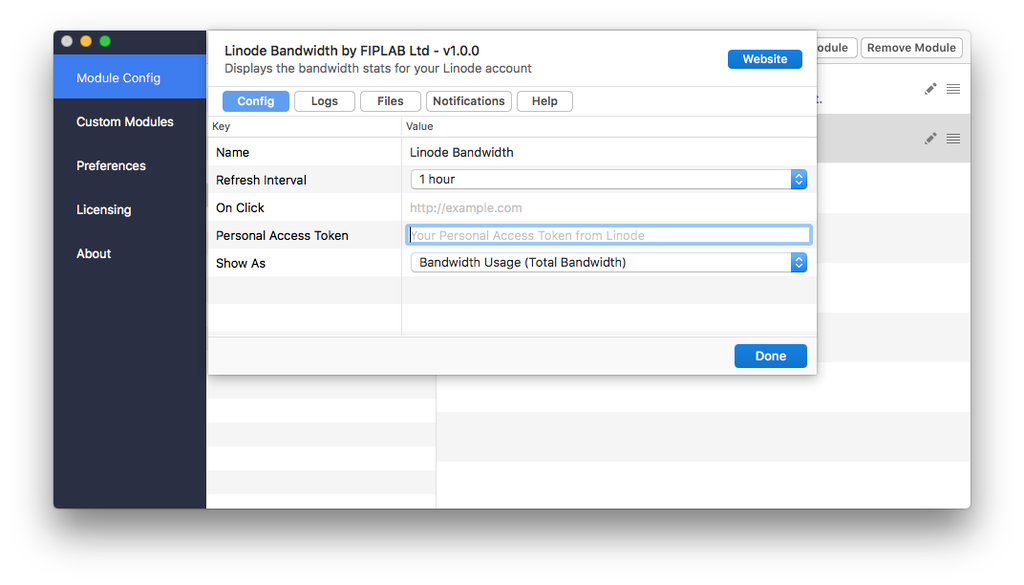

- Paste the copied Personal Access Token into the field by hitting `Command+V` or by `Right Clicking` the text field and selecting the `Paste` option.

**Tip** — You can reuse this Personal Access Token for multiple modules. You can `Right Click` the module in the list and select the `Duplicate` option to copy it and *ALL* of it’s configuration into a new module.

**Success** — You’re all set!

## Common Errors

Invalid Personal Access Token. Please verify the token and scopes then try again.

The token entered is invalid, expired, revoked, or does not have Read-Only access to the Account section. Follow the steps above to regenerate an access token.

Invalid response from server

There was an error while connecting to the Linode API. Please verify your internet connection then try again.